# Revenue Forecast - Exploratory Data Analysis Report

PLZ

May 12, 2016

### **Objectives:**

> To fully understanding the source data and making appropriate decisions about modeling, need to implement the following objectives:
> - Identify any data attributes with a significant percentage of missing values.
> - Determine attributes with missing values be excluded from analysis or imputed
> - Recommended logic for imputing values if applicable
> - Identify the data distribution of the initial dataset and any significant outliers related to:
>   - Daily Total Amount of Facility Referrals
>   - Daily Total Amount of Billed Cases
>   - Facility Referrals and/or Billed cases outliers Detection
>   - Understand the central tendency and spread of each distribution analysis.
> - Understanding daily trends of the following data attributes:
>   - Facility Referrals
>   - Billed Cases
>   - Summary, Carrier and Facility level trends
> - Measure the correlation between data attributes in order to find attributes with the greatest influence on Facility Referrals and Billed Cases.
> - Measure elapsed time between Facility Referrals and Billed Cases.
> - Create geography graphs of facility and member locations

### **Result:**

#### 1. Missing Value Analysis of Data Attributes

*The missing value analysis of each attributes(head 6) shown as below with percentage in descending order.(Here we have set 5% for missing value percentage metrics, that means if percentage exceeds 5%, we need to take some imputation action, but if percentage is less than 5% and greater than zero, consider to take exclusion action, otherwise, no need to take any action.) More detailed, please refer to csv file.*

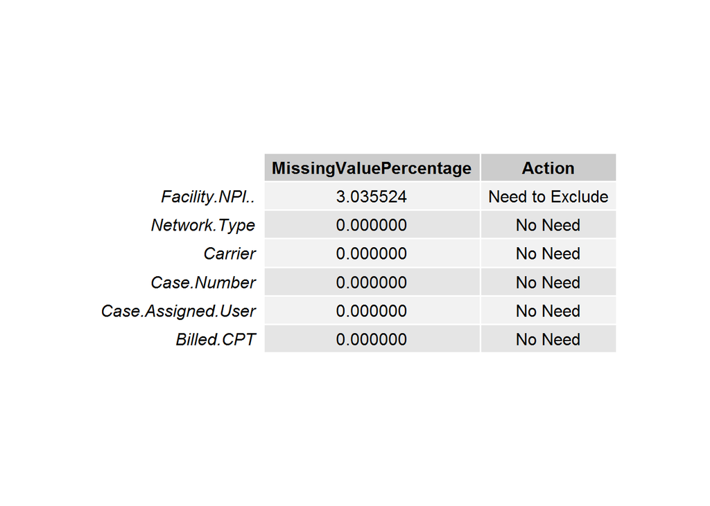

#### 2. Daily Facility Referrals Distribution And Outlier Detection

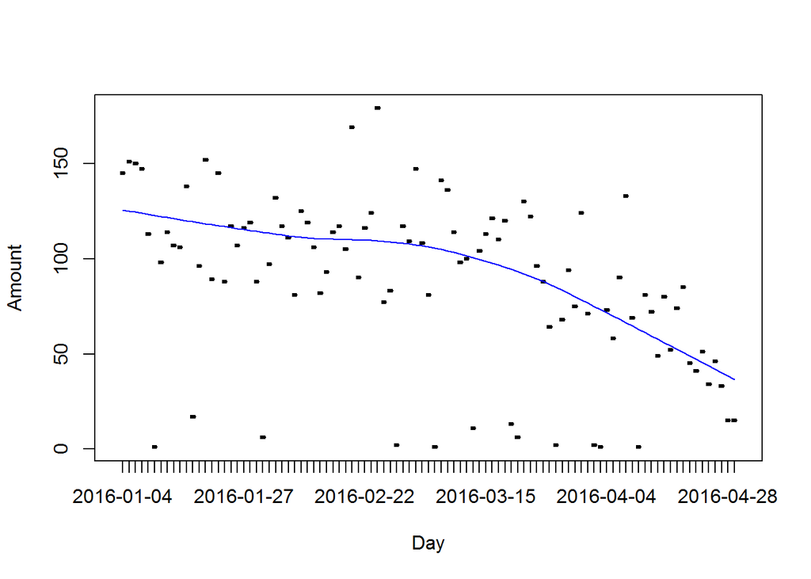

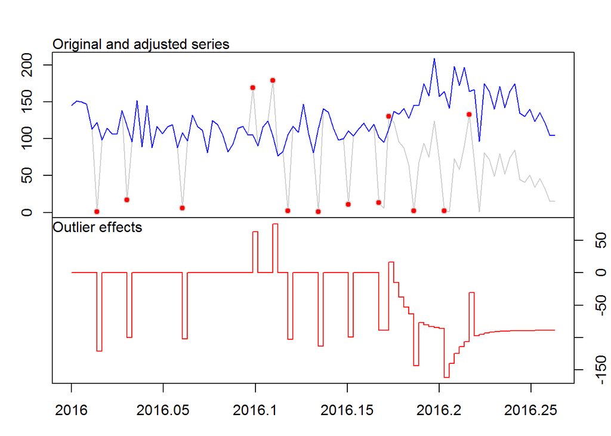

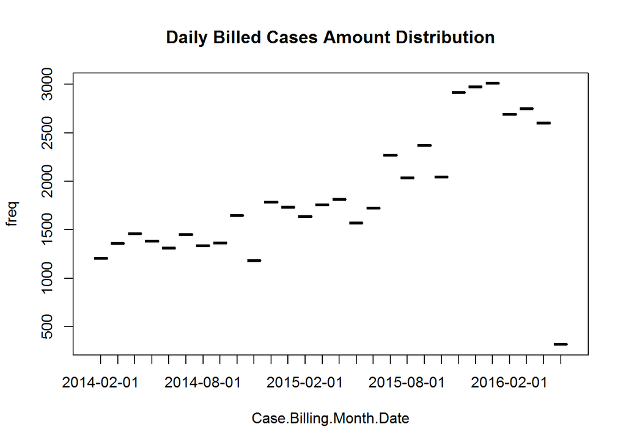

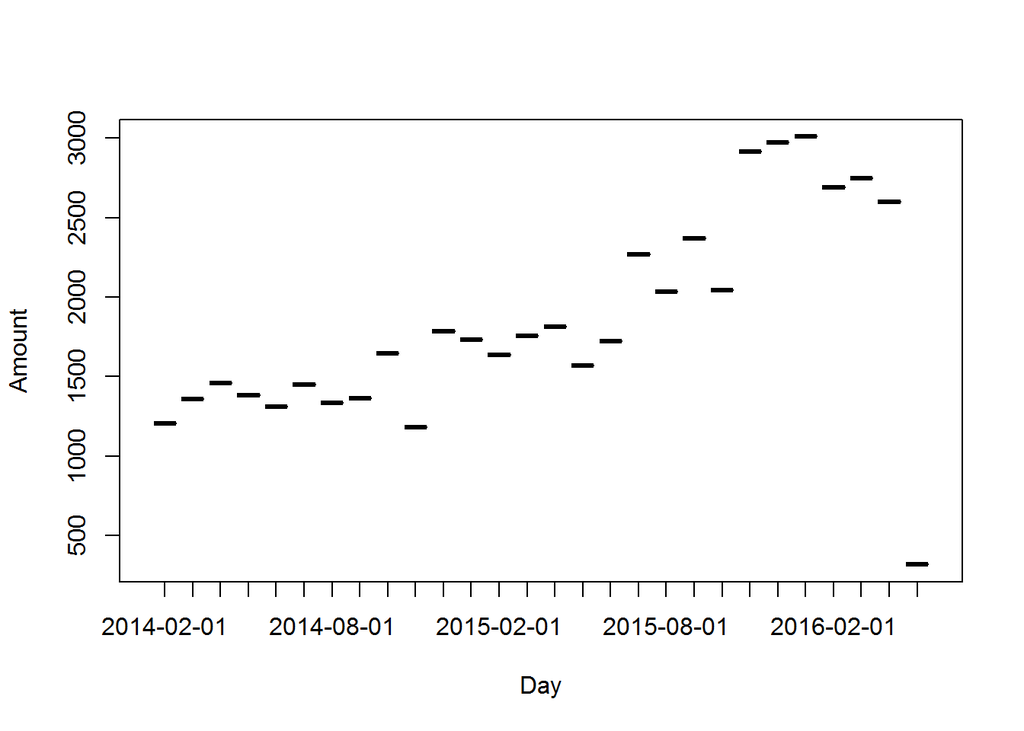

```
##   type ind    time    coefhat      tstat
## 1   LS   9 2014:09   350.4880   7.299517
## 2   AO  10 2014:10  -527.2330  -5.159854
## 3   LS  18 2015:06   481.7968   8.263462
## 4   TC  22 2015:10   866.3269   9.289142
## 5   LS  24 2015:12   304.1550   4.887894
## 6   AO  28 2016:04 -2279.1222 -20.872124
```

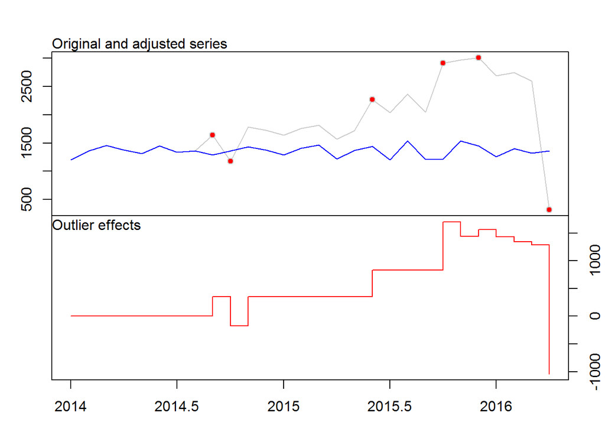

#### 4. Trend Summary

Here is correlation analysis between data attributes

```
##                        Carrier Case.Assigned.User   Case.Status
## Carrier             1.00000000        0.012591786 -0.0268944522
## Case.Assigned.User  0.01259179        1.000000000  0.0981121359
## Case.Status        -0.02689445        0.098112136  1.0000000000
## Reporting.Category -0.06493786        0.087559587  0.1838325985
## Actual.Revenue      0.02979419       -0.013020110  0.0048973824
## Facility            0.01983345       -0.014486557 -0.0008197573
## Facility.City      -0.01810104       -0.017392820  0.0011879978
## Member.Gender       0.01848770        0.006030367  0.0061522836
##                    Reporting.Category Actual.Revenue      Facility
## Carrier                  -0.064937857    0.029794191  0.0198334546
## Case.Assigned.User        0.087559587   -0.013020110 -0.0144865573
## Case.Status               0.183832598    0.004897382 -0.0008197573
## Reporting.Category        1.000000000   -0.020740702  0.0209626714
## Actual.Revenue           -0.020740702    1.000000000 -0.0056264603
## Facility                  0.020962671   -0.005626460  1.0000000000
## Facility.City            -0.006320432   -0.013000025  0.2501659974
## Member.Gender             0.006157237    0.008808592  0.0175093841
##                    Facility.City Member.Gender
## Carrier             -0.018101035   0.018487704
## Case.Assigned.User  -0.017392820   0.006030367
## Case.Status          0.001187998   0.006152284
## Reporting.Category  -0.006320432   0.006157237
## Actual.Revenue      -0.013000025   0.008808592
## Facility             0.250165997   0.017509384
## Facility.City        1.000000000   0.020765327
## Member.Gender        0.020765327   1.000000000
```

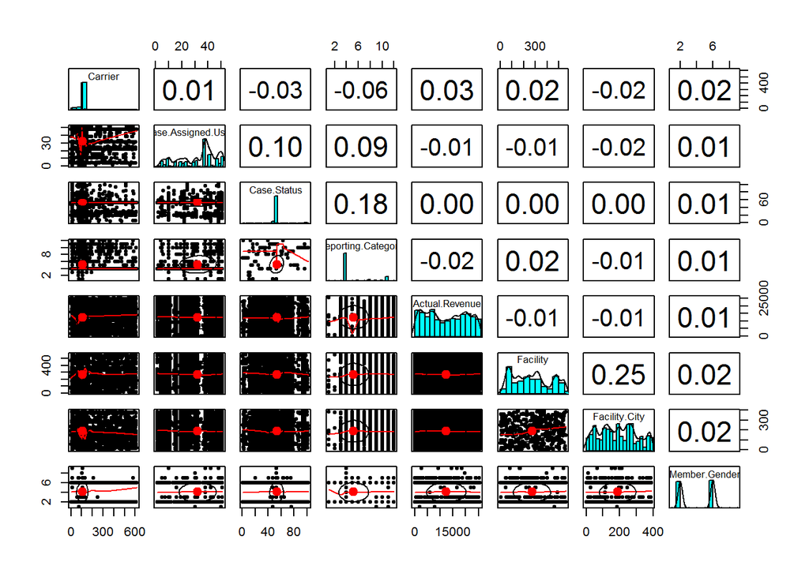